# Predict Diabetes using Ensemble Methods

# 7. Compare these two techniques.

Perhaps we can compare the two ensemble technique: Bagging and Boosting by comparing the feature important from each technique.

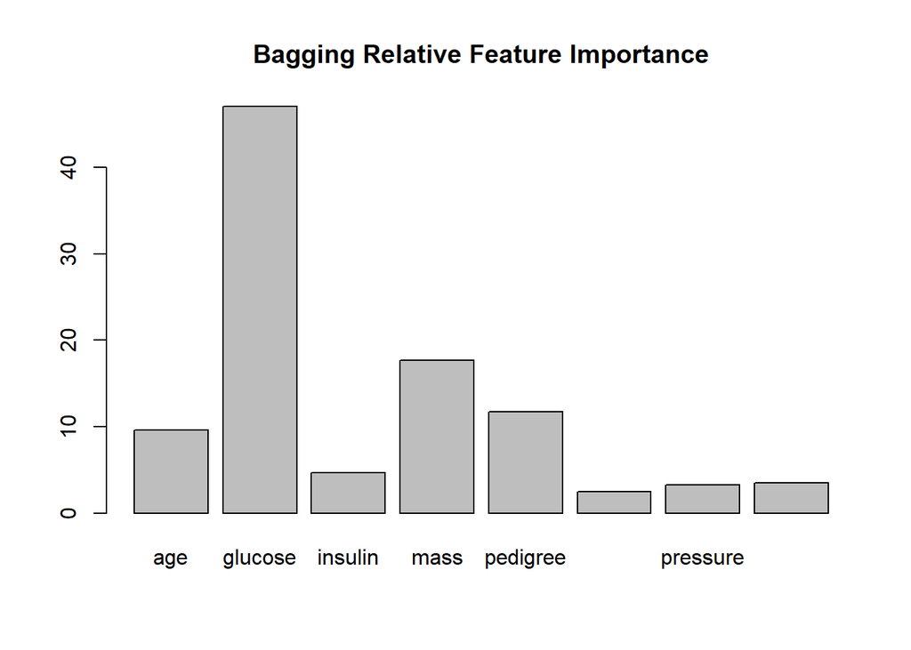

```r
mybag_adabag = adabag::bagging(diabetes ~ ., data = diabetes_train) # I had to re-run bagging method because ipred doesn't help calculate feature importance
barplot(mybag_adabag$importance, main = "Bagging Relative Feature Importance")
```

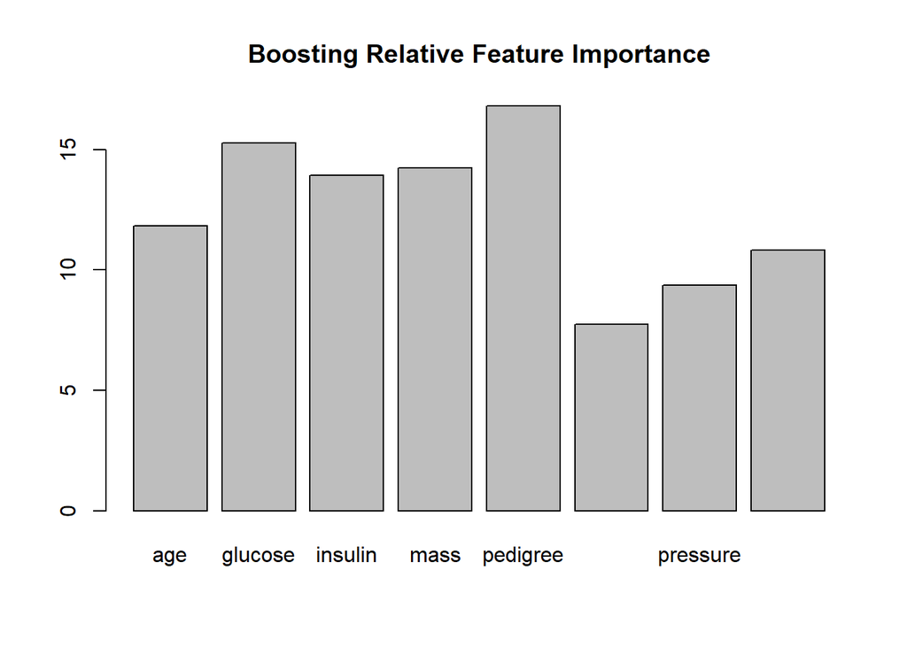

```r
barplot(myboosting$importance, main = "Boosting Relative Feature Importance")
```

We can see that feature `glucose` is disproportionately significant in the Bagging method, while the importance of features in Boosting method is more evenly spread. This result suggests that Bagging has a tendency to bias toward one predictor. I conclude that for a complex problem such as predicting diabetes, a single predictor should not reign over other predictors, therefore, boosting would be a better option to reduce bias in my model.

**References**

Lantz, Brett “Machine learning with R : discover how to build machine learning algorithms, prepare data, and dig deep into data prediction techniques with R”

http://lumen.regis.edu/record=b1734246~S3.

Newman, D.J. & Hettich, S. & Blake, C.L. & Merz, C.J. (1998). UCI Repository of machine learning databases [http://www.ics.uci.edu/~mlearn/MLRepository.html]. Irvine, CA: University of California, Department of Information and Computer Science.